# 地理信息系统与R－空间统计学入门

Miao Yu

2015年4月28日

除了作图，还是要谈一点空间统计学入门级的东西（其实我就知道这么多）而我们的目标问题是空间中点分布及其与相关因素的关系。说简单点就是给你一堆空间里的点，这些点的分布是否随机（这是个分布的假设检验问题），其分布不随机的话找出相关的变量并建模（这是个建模问题）。好，先看基本概念：

## 空间密度

均匀分布定义：

$\bar \lambda = \frac{n(x)}{area(W)}$

不均匀分布：密度对于面积的积分

空间里某点的分布我们用空间密度来描述，记住这个就可以了。

## 空间随机性的检验

一般来说，我们认为均匀泊松点过程，也就是完全空间随机（CSR）是空间随机性假设检验的空分布，其严格定义如下：

- N个点落入B区域是一个泊松随机变量
- B区域内点个数的期望为密度$\lambda$与B面积的乘积
- 如果B1与B2不相连，那么其中个数是独立随机变量
- 如果某区域B中有N个点，那么这N个点在B中是独立均匀分布的

```r
# 载入spatstat包，该包常用来进行空间统计分析
library(spatstat)
```

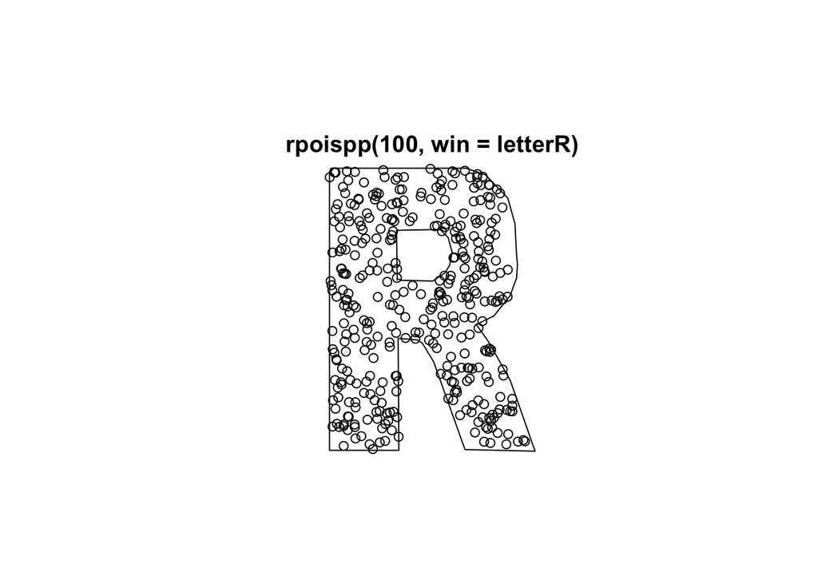

```r
data(nztrees)
data(letterR)
# rpoispp用来模拟一个均匀泊松点过程，参数为空间密度，窗口可自定义
plot(rpoispp(100, win = letterR))
```

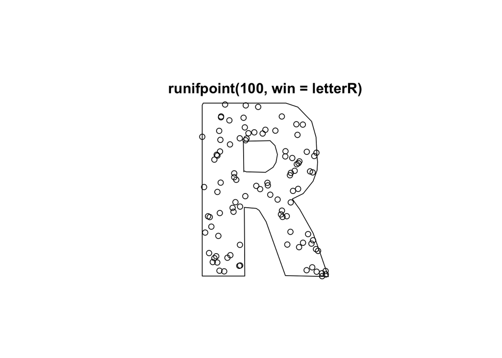

```r
# runifpoint用来模拟一个固定数量的均匀泊松点过程
plot(runifpoint(100, win = letterR))
```

```r
# 一般可用来作为空间分布的空假设来进行卡方检验
quadrat.test(nztrees, nx = 3, ny = 2)
```

```
##
##  Chi-squared test of CSR using quadrat counts
##  Pearson X2 statistic
##
## data:  nztrees
## X2 = 6.3721, df = 5, p-value = 0.5434
## alternative hypothesis: two.sided
##
## Quadrats: 3 by 2 grid of tiles
```

## Kolmogorov-Smirnov 检验

CSR的独立假设通常是不能满足的，因此用这种方法进行检验功效不足，一般可以用Kolmogorov-Smirnov 检验，制定一个经验点分布模式来进行检验。Berman 提出了另一个检验，如果模型正确，两条垂直线会比较接近

```r
# 对假设分布的优度检验
(KS <- cdf.test(nztrees, "x"))
```

```
##
##  Spatial Kolmogorov-Smirnov test of CSR in two dimensions
##
## data:  covariate 'x' evaluated at points of 'nztrees'
##      and transformed to uniform distribution under CSR
## D = 0.11, p-value = 0.2319
## alternative hypothesis: two-sided
```

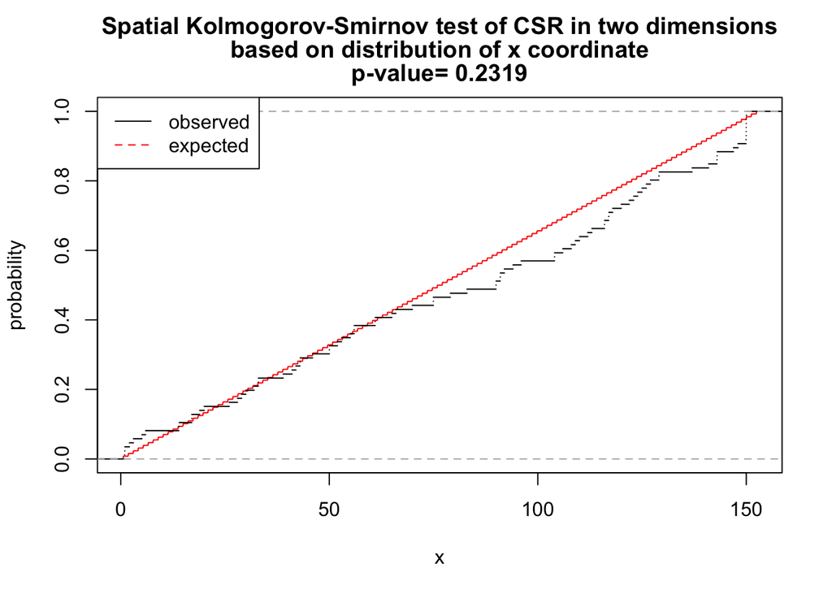

```r
plot(KS)
```

```r
# 相关因素的优度检验
data(copper)
X <- copper$SouthPoints
L <- copper$SouthLines
D <- distmap(L, eps=1)
# test of CSR
(BM <- berman.test(X, D))
```

```
##
##  Berman Z1 test of CSR in two dimensions
##
## data:  covariate 'D' evaluated at points of 'X'
## Z1 = 0.4696, p-value = 0.6386
## alternative hypothesis: two-sided
```

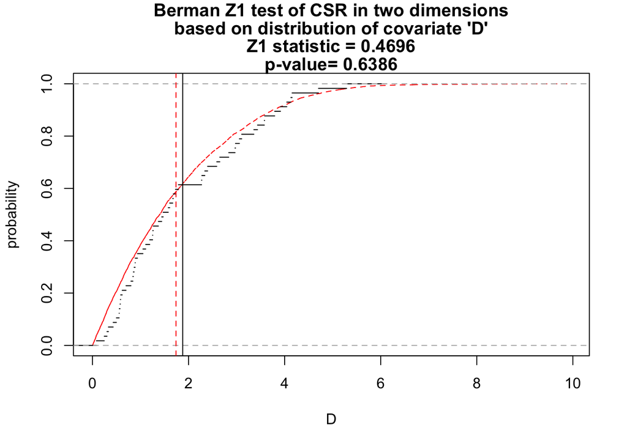

```r
plot(BM)
```

```r
(BM2 <- berman.test(X, D, "Z2"))
```

```
##
##  Berman Z2 test of CSR in two dimensions
##
## data:  covariate 'D' evaluated at points of 'X'
##   and transformed to uniform distribution under CSR
## Z2 = 1.13, p-value = 0.2585
## alternative hypothesis: two-sided
```

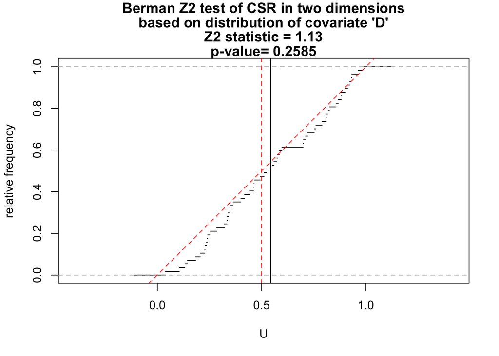

```r
plot(BM2)
```

## 空间统计建模

如果空间点的分布符合某个分布，那么下一步就是对这个分布的参数进行估计，或者说寻找这个参数的影响因子。一般而言，需要进行极大似然估计，结果可以得到某个参数或者这个参数的模型。模型的选择与检验与常规的线性回归相似：模型选择可以使用方差分析，也可以使用其他的高级方法来选择变量；检验则是对残差或标准误作图，观察是否像噪音。同时，我们也可以对模型进行模拟观察生成的数据。当然，上面说的仅仅是对点的分布而言。而点分布模式也可以用fly plot或者Morishita plot来直观检测。

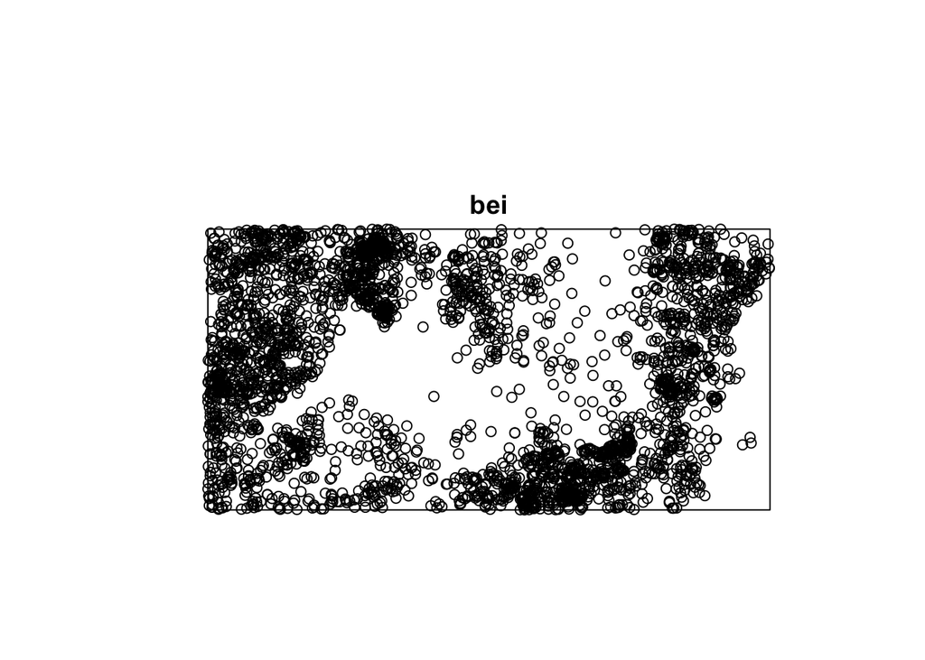

```r
# 原始数据
plot(bei)
```

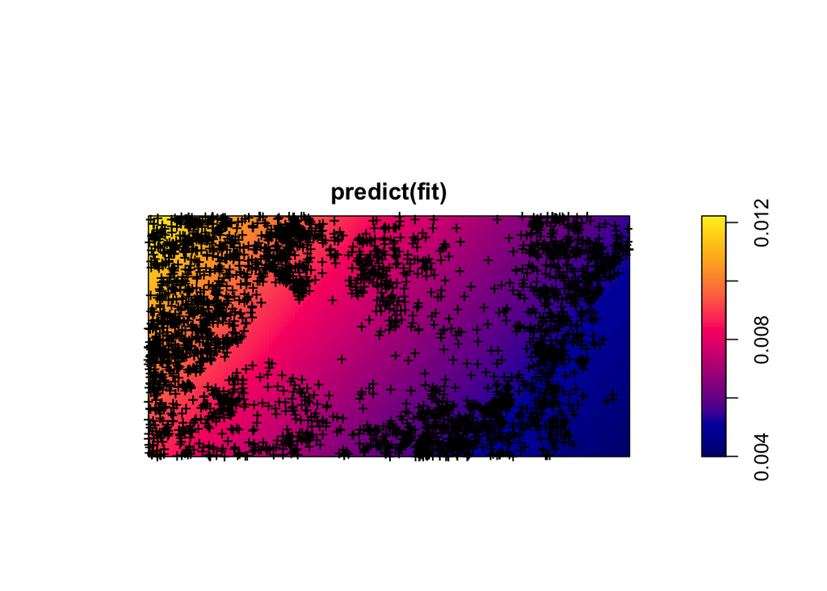

```r
# 构建模型
fit <- ppm(bei, ~x + y)
# 观察拟合效果
plot(predict(fit))
plot(bei, add = TRUE, pch = "+")
```

```r
# 观察标准误
SE <- predict(fit, type = "se")
```

```
## Outdated syntax: type='se' should be replaced by se=TRUE; then the standard error is predict(...)$se
```

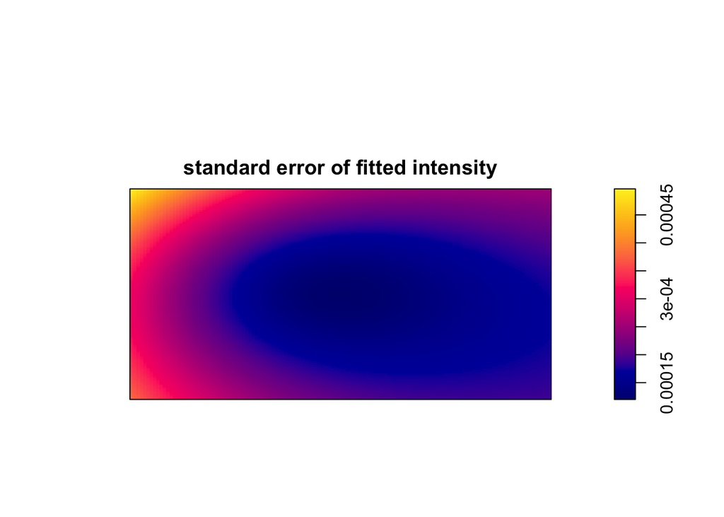

```r
plot(SE, main = "standard error of fitted intensity")
```

```r
# 数据模拟
fitprop <- ppm(bei, ~offset(log(slope)), covariates = list(slope = bei.extra$grad))
X <- rmh(fitprop)
```

```
## Extracting model information...Evaluating trend...done.
## Checking arguments..determining simulation windows...Evaluating trend integral...
```

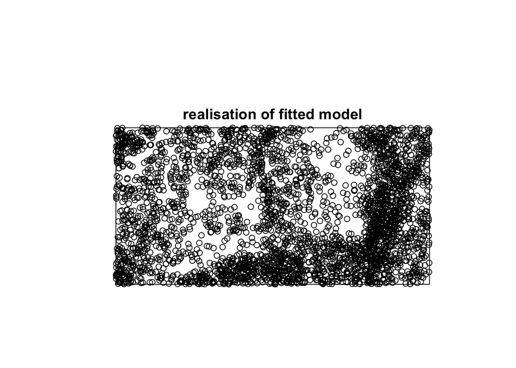

```r
plot(X, main = "realisation of fitted model")
```